# TidyTues 1

Author

Madigan Boborci

## Introduction:

This is the first Tidy Tuesday Assignment. The dataset is about the lead levels in the water in Flint, Michigan.

### Libraries

```r
library(tidyverse)
library(ggplot2)
library(dplyr)
library(patchwork)
library(here)
```

### Load in the TidyTuesday Data

```r
flint_mdeq <- readr::read_csv('https://raw.githubusercontent.com/rfordatascience/tidytuesday/main/data/2025/2025-11-04/flint_mdeq.csv')
flint_vt <- readr::read_csv('https://raw.githubusercontent.com/rfordatascience/tidytuesday/main/data/2025/2025-11-04/flint_vt.csv')
```

### Make a Plot

We are supposed to make any visualization we would like, but we have to learn something new. Here I make a base plot that has the density set as the amount of times each value is recorded and the lead measurements in ppb on the x axis.

```r
vt_plot<-ggplot(data = flint_vt, aes(x = lead, y=after_stat(count))) +       #define x axis, make y axis easier to understand
      geom_density() +
  coord_cartesian (ylim=c(0,20))+
      labs(title ="Frequency of Lead Measurements in Flint",
           x="Lead Measurement (ppb)",
           y="Frequency")
```

Here, I looked up any lead value that was acceptable, and found that public water suppliers have a grace window of safely consumable water under [15 ppb] (https://facs.com/blog/guide-to-ppb-and-safe-lead-levels-in-water-understanding-the-standards/). I wanted to emphasize this so that it was clear just how much lead is in the water.

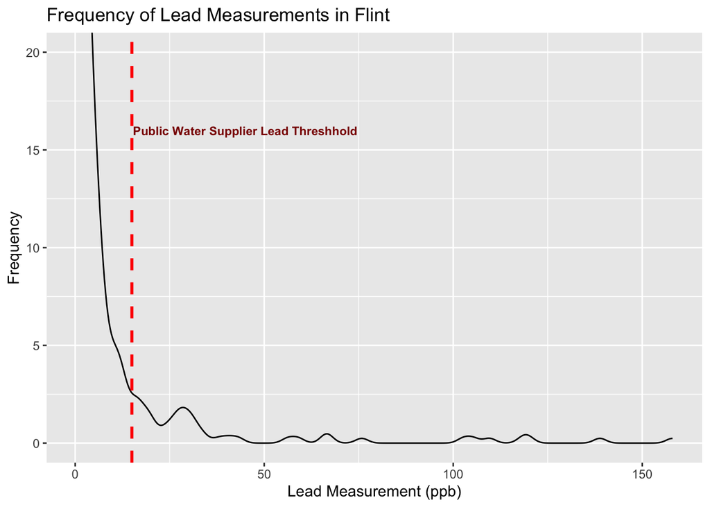

Figure 1: Frequency of Lead Measurements in PPB

```r
vt_plot+
  geom_vline(
    xintercept = 15,          # where line intercepts x
    linetype = "dashed",
    color = "red",
    linewidth = 1
  )+
  annotate(                  # adding a label
    "text",
    x = 45,                  # Choose where text will go
    y = 16,
    label = "Public Water Supplier Lead Threshhold",     #what I want it to say
    color = "darkred",
    size = 3,
    fontface = "bold"
  )

ggsave(here("TidyTuesday","Outputs","TT_1.png"),width=7,height=5)
```

### Summary and What’s New

Here in Figure 1 we can see how many measurements read far over the acceptable level of lead, even for a public water distributor. I made my first density plots for both of my assignments this week, so that was new for me. In addition, on this plot I learned how to change the y axis to something more useful, as well as add static annotations to draw attention to specific portions of my plots.